# Human Resources-related News Discovery: TruValue Labs Spotlight Data

Boyie

March 31, 2023

# Key information in TruValue Spotlight data

1. It contains news headlines and and brief content (bullet points) related to [SASB Standards](https://www.sasb.org/standards/materiality-finder/?lang=en-us). There are 118,386 articles in total.
2. I subset the “Human Capital” sub-category, thus the number of articles are 17,373.
3. Truvalue Labs constructs “pulse score” for each news article based on its methodology. It describes is as “The Pulse Score measures the near-term performance changes that highlight opportunities and controversies.”
- https://insight.factset.com/resources/at-a-glance-factset-truvalue-sasb-scores-datafeed
- https://truvalue-sasb-codified-edition.groovehq.com/help/how-are-scores-calculated-for-individual-categories-and-overall-for-a-company
4. We’ve identified diversity washers, the following sections we are going to see some examples that they are described in the news.

```r
iff <- function(cond, res) ifelse(cond, res, NA_real_)
# load truvalue labs spotlight (news) data
df.tv_spotlight <- read_csv(paste0(path_dropbox, "data/truevaluelabs_data/truvalue/linked_tv_data/tv_spotlight_v2_linked_from_Qianqian/spotlight_latest.csv")) %>%
  select(-1)

# load the final_merged data (already identified diversity washers)
df.final_merge <- readRDS(paste0(path_dropbox, "data/data_merged/data_merged_final.RDS"))
```

## Data Preview

```r
# discover useful data
colnames(df.tv_spotlight)
```

```
##  [1] "X.TV_ORG_ID."                     "X.TV_SPOTLIGHT_ID."
##  [3] "X.TV_GROUP_ID."                   "X.TRIGGER_DATE."
##  [5] "X.FIRST_ARTICLE_DATE."            "X.FINAL_ARTICLE_DATE."
##  [7] "X.TV_ORG_NAME."                   "X.SPOTLIGHT_STATUS."
##  [9] "X.PRIMARY_SPOTLIGHT."             "X.SPOTLIGHT_CATEGORY."
## [11] "X.MATERIAL_CATEGORY."             "X.PRIMARY_ARTICLE_HEADLINE."
## [13] "X.PRIMARY_ARTICLE_BULLETPOINTS."  "X.PRIMARY_ARTICLE_SOURCE."
## [15] "X.PRIMARY_ARTICLE_URL."           "X.ORGANIZATION_VOLUME_THRESHOLD."
## [17] "X.SPOTLIGHT_TRIGGER_DATE_VOLUME." "X.TOTAL_SPOTLIGHT_VOLUME."
## [19] "X.PULSE_BEFORE_FIRST_ARTICLE."    "X.PULSE_ON_TRIGGER."
## [21] "X.PULSE_ON_FINAL_ARTICLE_DATE."   "X.MEAN_PULSE_SCORE."
## [23] "permno"                           "gvkey"
```

```r
# categories
df.tv_spotlight %>% pull(X.SPOTLIGHT_CATEGORY.) %>% unique()
```

```
##  [1] "BusinessEthics"
##  [2] "AccessAndAffordability"
##  [3] "ProductQualityAndSafety"
##  [4] "SupplyChainManagement"
##  [5] "DataSecurity"
##  [6] "MaterialsSourcingAndEfficiency"
##  [7] "ProductDesignAndLifecycleManagement"
##  [8] "EnergyManagement"
##  [9] "GHGEmissions"
## [10] "WaterAndWastewaterManagement"
## [11] "WasteAndHazardousMaterialsManagement"
## [12] "EcologicalImpacts"
## [13] "CustomerWelfare"
## [14] "EmployeeHealthAndSafety"
## [15] "EmployeeEngagementDiversityAndInclusion"
## [16] "ManagementOfTheLegalAndRegulatoryEnvironment"
## [17] "SellingPracticesAndProductLabeling"
## [18] "LaborPractices"
## [19] "PhysicalImpactsOfClimateChange"
## [20] "CompetitiveBehavior"
## [21] "BusinessModelResilience"
## [22] "HumanRightsAndCommunityRelations"
## [23] "CustomerPrivacy"
## [24] "SystemicRiskManagement"
## [25] "CriticalIncidentRiskManagement"
## [26] "AirQuality"
```

```r
category_hr <- c("EmployeeEngagementDiversityAndInclusion", "EmployeeHealthAndSafety", "LaborPractices")
```

```r
# the TV Spotlight data is in a finer level, we collapse it into yearly data
df.tv_hr <- df.tv_spotlight %>%
  filter(X.SPOTLIGHT_CATEGORY. %in% category_hr) %>%
  mutate(year = lubridate::year(X.FIRST_ARTICLE_DATE.))

df.tv_hr %>%
  select(permno, year, X.SPOTLIGHT_CATEGORY., X.MEAN_PULSE_SCORE., X.PRIMARY_ARTICLE_HEADLINE.) %>%
  head(10) %>%
  kbl() %>%
  kable_styling()
```

| permno | year | X.SPOTLIGHT_CATEGORY. | X.MEAN_PULSE_SCORE. | X.PRIMARY_ARTICLE_HEADLINE. |
| --- | --- | --- | --- | --- |
| 16555 | 2021 | EmployeeHealthAndSafety | 92.42 | Universal : to Acquire Shank’s Extracts, Inc., a Well-Established Provider of Flavoring and Extracts (Form 8-K) |
| 92776 | 2020 | EmployeeHealthAndSafety | 81.40 | Westport Fuel Systems Announces the Temporary Suspension of Production in Brescia, Italy |
| 92776 | 2020 | EmployeeHealthAndSafety | 81.29 | Westport Fuel Systems Announces Change to Virtual Annual and Special Meeting of Shareholders |
| 89574 | 2022 | EmployeeEngagementDiversityAndInclusion | 63.08 | PRA GroupPRA Group Wins Stevie(R) Bronze Medal at International Business Award 2022 |
| 89574 | 2021 | EmployeeHealthAndSafety | 86.46 | PRA Group finds sustainable home at The HALO Kilmarnock |
| 49373 | 2020 | LaborPractices | 52.55 | Tax return deadline 2020: How to file an extension, estimate returns and more |
| 49373 | 2022 | EmployeeEngagementDiversityAndInclusion | 67.22 | H&R Block Announces New Benefits to Advance Inclusivity for LGBTQ+ Community |
| 49373 | 2021 | EmployeeEngagementDiversityAndInclusion | 54.44 | ODP : Brit + Co Launches Selfmade Season Three in Collaboration with Office Depot and Block Advisors |
| 49373 | 2020 | LaborPractices | 60.49 | I ran my taxes through Credit Karma Tax and H&R Block. Here’s how they compare on price, ease of use, and refunds. |
| 49373 | 2021 | EmployeeEngagementDiversityAndInclusion | 70.76 | September 8, 2021 News: H&R Block makes meaningful progress towards 1 million volunteer hours, supporting 500,000 small business owners and 500 communities in second corporate responsibility report |

```r
df.tv_hr %>%
  select(year, X.MEAN_PULSE_SCORE.) %>%
  summary()
```

```
##       year      X.MEAN_PULSE_SCORE.
##  Min.   :2015   Min.   : 0.00
##  1st Qu.:2019   1st Qu.:43.51
##  Median :2020   Median :56.49
##  Mean   :2020   Mean   :57.96
##  3rd Qu.:2021   3rd Qu.:75.17
##  Max.   :2022   Max.   :99.95
```

## Data coverage

- For diversity washers, it covers about $10\%$ of the firm-year level observations.
- For all firm-year observations, the coverage rate is about $7\%$
- Though the earliest news can date back to 2015, but most of the news are not there until 2019-ish.

```r
# to know the coverage
df.cov <- df.tv_hr %>%
  group_by(permno, year) %>%
  summarize(score = mean(X.MEAN_PULSE_SCORE.)) %>%
  ungroup()
# firm-year level coverage: ~ 7% HR related news
df.cov_all <- df.final_merge %>%
  select(permno, year) %>%
  distinct() %>%
  left_join(df.cov, by = c("permno", "year"))

mean(!is.na(df.cov_all$score))
```

```
## [1] 0.07478872
```

```r
# firm-year level coverage in diversity washers: ~ 10% HR related news
df.cov_dw <- df.final_merge %>%
  filter(diversity_washer == 1) %>%
  select(permno, year) %>%
  distinct() %>%
  left_join(df.cov, by = c("permno", "year"))

mean(!is.na(df.cov_dw$score))
```

```
## [1] 0.1007549
```

# Selected examples

- We identified diversity washers, and in the following section we are going to see their HR-related news.
- The news headlines and the identified company names are presented along with the pulse score.
- Note that the absolute value of pulse score itself does not mean the news is positive or negative. The sign is reflected by the pulse score and the insight score together, i.e. if the pulse score is higher than the current insight score, then it means there is a positive event happens, and drives the insight score up. As TruValue Labs depicts:

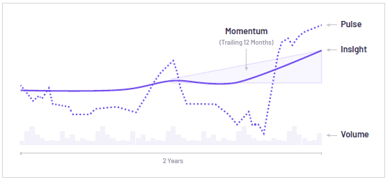

- A diversity washer in 2020 is not necessary to be a diversity washer in other years.

```r
df.dw_news <- df.final_merge %>%
  filter(diversity_washer == 1) %>%
  select(permno, year) %>%
  left_join(df.tv_hr, by = c("permno", "year")) %>%
  tidyr::drop_na(X.TV_ORG_ID.)

# 10 examples
set.seed(3219)
df.dw_news %>%
  select(permno, year, X.TV_ORG_NAME., X.SPOTLIGHT_CATEGORY., X.PRIMARY_ARTICLE_HEADLINE., X.MEAN_PULSE_SCORE.) %>%
  slice(sample(1:nrow(df.dw_news), 10)) %>%
  kbl() %>%
  kable_styling()
```

| permno | year | X.TV_ORG_NAME. | X.SPOTLIGHT_CATEGORY. | X.PRIMARY_ARTICLE_HEADLINE. | X.MEAN_PULSE_SCORE. |
| --- | --- | --- | --- | --- | --- |
| 57904 | 2020 | Aflac Inc | LaborPractices | Aflac Life Insurance Review 2020 | 46.88 |
| 52038 | 2020 | Sysco Corp | LaborPractices | Sysco lays off, furloughs workers in response to coronavirus fallout | 50.30 |
| 93436 | 2021 | Tesla Inc | EmployeeHealthAndSafety | Tesla plant had hundreds of COVID cases after Musk’s defiant reopening, records show | 59.92 |
| 14338 | 2018 | Hilton Worldwide Holdings Inc | LaborPractices | Workers ratify new contract with 7 downtown hotels; strike drags on at 19 more | 61.40 |
| 10107 | 2020 | Microsoft Corp | EmployeeHealthAndSafety | LinkedIn to Cut 960 Jobs as Pandemic Curtails Hiring Demand | 70.82 |
| 89626 | 2021 | CME Group Inc | LaborPractices | Fired ICAP Broker Sued the Firm for Millions. Or So He Thought | 30.61 |
| 15315 | 2016 | GoDaddy Inc | EmployeeEngagementDiversityAndInclusion | GoDaddy Joins Path Forward Return-to-Work Program; Offers Internships for Mid-Career Professionals | 72.02 |
| 52230 | 2020 | Robert Half International Inc | EmployeeEngagementDiversityAndInclusion | HSBC Singapore to have women in 40 per cent of its most senior roles by 2022 | 71.62 |
| 79668 | 2021 | Belden Inc | EmployeeEngagementDiversityAndInclusion | Videogame developer Tripwire Interactive replaces CEO who voiced support for Texas abortion law | 62.88 |
| 93101 | 2020 | Lear Corp | LaborPractices | UPDATE 3-GM kicks off restart in Mexico as Lear Corp readies for return | 47.37 |

```r
# another 10 examples
set.seed(6789)
df.dw_news %>%
  select(permno, year, X.TV_ORG_NAME., X.SPOTLIGHT_CATEGORY., X.PRIMARY_ARTICLE_HEADLINE., X.MEAN_PULSE_SCORE.) %>%
  slice(sample(1:nrow(df.dw_news), 10)) %>%
  kbl() %>%
  kable_styling()
```

| permno | year | X.TV_ORG_NAME. | X.SPOTLIGHT_CATEGORY. | X.PRIMARY_ARTICLE_HEADLINE. | X.MEAN_PULSE_SCORE. |
| --- | --- | --- | --- | --- | --- |
| 26825 | 2021 | Kellogg Co | LaborPractices | Kellogg to permanently replace striking workers as union rejects new contract | 35.99 |
| 82775 | 2020 | Hartford Financial Services Group Inc | EmployeeHealthAndSafety | Best Small Business Insurance Options in Florida: | 39.47 |
| 77637 | 2020 | Franklin Covey Co | EmployeeEngagementDiversityAndInclusion | FRANKLIN COVEY : Best Western® Hotels & Resorts Selects FranklinCovey’s "Gold Standard" Leadership Development Curriculum to Elevate Leadership Excellence in 2,000 Plus North American Hoteliers | 68.75 |
| 76226 | 2018 | ViacomCBS | EmployeeEngagementDiversityAndInclusion | CBS faces a New York sexual misconduct probe tied to ex-CEO Leslie Moonves | 16.12 |
| 55976 | 2020 | Walmart Inc | EmployeeHealthAndSafety | Walmart s same-store sales rise 10 , online revenues surge 74 | 58.00 |
| 91461 | 2019 | Western Union Co | EmployeeEngagementDiversityAndInclusion | Western Union : Foundation Unveils "Opportunity Beyond Borders" to Empower Forcibly Displaced and Marginalized Youth | 34.96 |
| 61815 | 2018 | Noble Energy Inc | EmployeeHealthAndSafety | Suit outlines safety concerns at Anadarko Petroleum Corp. | 49.85 |
| 83906 | 2021 | Stericycle Inc | EmployeeEngagementDiversityAndInclusion | Stericycle CEO Cindy J. Miller Wins Gold Stevie® Award in the 18th Annual Stevie Awards for Women in Business | 57.69 |
| 89533 | 2019 | Wynn Resorts Ltd | EmployeeEngagementDiversityAndInclusion | Wynn Resorts to face Massachusetts regulators in bid to save gaming license after last year’s #MeToo scandal | 29.55 |
| 81740 | 2020 | Sinclair Broadcast Group Inc | LaborPractices | Fox Sports Wisconsin owner offers financial relief for freelancers cited by Brian Anderson | 49.86 |

## Observations

- Though looking at pulse score itself does not help to realize whether the underlying event is positive or negative (since we have not yet combine the pulse score and the insight score together), we can take a look at some cases.

### Tesla

```r
df.final_merge %>%
  filter(permno == 93436) %>%
  select(year, diversity_washer) %>%
  kbl() %>%
  kable_styling()
```

| year | diversity_washer |
| --- | --- |
| 2011 | 0 |
| 2012 | 0 |
| 2013 | 0 |
| 2014 | 0 |
| 2015 | 0 |
| 2016 | 1 |
| 2017 | 0 |
| 2018 | 1 |
| 2019 | 1 |
| 2020 | 1 |
| 2021 | 1 |

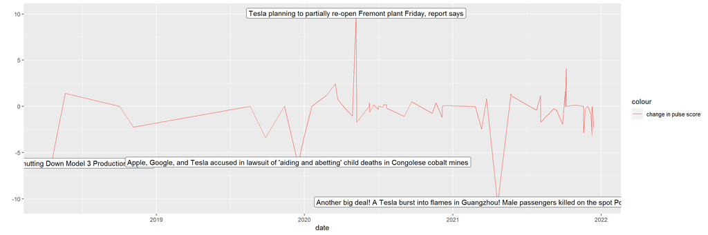

```r
# see the change in score
df.tesla <- df.dw_news %>%
  filter(permno == 93436) %>%
  arrange(X.FIRST_ARTICLE_DATE.) %>%
  mutate(pulse_diff = X.PULSE_ON_FINAL_ARTICLE_DATE. - X.PULSE_ON_TRIGGER.) %>%
  mutate(headline = iff(abs(pulse_diff) > 5, X.PRIMARY_ARTICLE_HEADLINE.))

df.tesla %>%
  ggplot(aes(x = X.FIRST_ARTICLE_DATE., y = pulse_diff))+
  geom_line(aes(y = pulse_diff, col = "change in pulse score"))+
  geom_label(label = df.tesla$headline,
             nudge_x = 0.25, nudge_y = 0.25,
             check_overlap = T)+
  labs(x = "date", y = "")
```